# AI_assignment_1

### Part1 I overlaid Philadelphia's transportation data from 2007 to 2017 with the boundaries of Philadelphia's census tracts to analyze the safety levels across the city's neighborhoods.

第一部分 我将2007年至2017年费城交通数据与该市人口普查区划边界进行叠加，以分析全市各社区的安全水平。

```python
import geopandas as gpd
crash_gdf = gpd.read_file("data/data/crash_data_collision_crash_2007_2017.shp")


census_gdf = gpd.read_file("data/data/philadelphia-census-tract.shp")
```

This step is to Review the column names to confirm which fields are included (such as year, month, day of the week, coordinates, etc.).

检查列名以确认包含哪些字段（例如年、月、星期几、坐标等）。

```python
print(crash_gdf.columns)
print(crash_gdf.head())
```

```
Index(['county_nam', 'objectid_1', 'objectid', 'crn', 'district', 'county',
       'municipali', 'crash_year', 'crash_mont', 'day_of_wee', 'time_of_da',
       'hour_of_da', 'illuminati', 'weather', 'road_condi', 'collision_',
       'relation_t', 'work_zone_', 'work_zon_1', 'work_zon_2', 'intersect_',
       'tcd_type', 'location_t', 'urban_rura', 'fatal_coun', 'injury_cou',
       'person_cou', 'total_unit', 'sch_bus_in', 'sch_zone_i', 'latitude',
       'longitude', 'arrival_tm', 'cons_zone_', 'dispatch_t', 'est_hrs_cl',
       'lane_close', 'ln_close_d', 'ntfy_hiwy_', 'spec_juris', 'tcd_func_c',
       'tfc_detour', 'workers_pr', 'wz_close_d', 'wz_flagger', 'wz_ln_clos',
       'wz_moving', 'wz_other', 'wz_shlder_', 'vehicle_co', 'automobile',
       'motorcycle', 'bus_count', 'small_truc', 'heavy_truc', 'suv_count',
       'van_count', 'bicycle_co', 'maj_inj_co', 'mod_inj_co', 'min_inj_co',
       'tot_inj_co', 'unk_inj_de', 'unk_inj_pe', 'driver_cou', 'driver_c_1',
       'driver_c_2', 'driver_c_3', 'driver_c_4', 'driver_c_5', 'driver_c_6',
       'driver_c_7', 'unbelted_o', 'unb_death_', 'unb_maj_in', 'belted_dea',
       'belted_maj', 'mcycle_dea', 'mcycle_maj', 'bicycle_de', 'bicycle_ma',
       'ped_count', 'ped_death_', 'ped_maj_in', 'max_severi', 'comm_veh_c',
       'dec_lat', 'dec_long', 'rdwy_surf_', 'wz_law_off', 'geometry'],
      dtype='object')
  county_nam  objectid_1  objectid         crn  district  county  municipali  \
0       None        9498    128198  2016019772         6      67       67301
1       None        9570    128432  2016013724         6      67       67301
2       None        9642    128688  2016038282         6      67       67301
3       None        9714    128842  2016052220         6      67       67301
4       None        9786    128975  2016087187         6      67       67301

   crash_year  crash_mont  day_of_wee  ...  ped_count  ped_death_  ped_maj_in  \
0        2016           2           2  ...          1           0           0
1        2016           1           3  ...          0           0           0
2        2016           3           5  ...          0           0           0
3        2016           2           5  ...          0           0           0
4        2016           8           6  ...          1           0           0

   max_severi  comm_veh_c  dec_lat  dec_long rdwy_surf_ wz_law_off  \
0           3           0  40.0628  -75.0577       None       None
1           3           0  40.0822  -74.9669       None       None
2           0           1  39.9751  -75.1946       None       None
3           8           0  40.0357  -75.2171       None       None
4           4           0  39.9511  -75.1721       None       None

                   geometry
0  POINT (-75.0577 40.0628)
1  POINT (-74.9669 40.0822)
2  POINT (-75.1946 39.9751)
3  POINT (-75.2171 40.0357)
4  POINT (-75.1721 39.9511)

[5 rows x 91 columns]
```

#### This step filters the accident dataset to include only the accidents that happened in May 2015, keeping only the relevant time period for analysis.

#### 这一步是从事故数据中筛选出 2015 年 5 月份发生的事故点，只保留需要分析的时间范围。

```python
subset = crash_gdf[(crash_gdf["crash_year"] == 2015) & (crash_gdf["crash_mont"] == 5)]
subset = subset.to_crs(census_gdf.crs)   # ✅ 再保证和 census 一致
```

#### Align geographic coordinates

对齐地理坐标并检查对不对

```python
print(crash_gdf.crs)
print(census_gdf.crs)
```

```
EPSG:2272
EPSG:2272
```

```python
crash_gdf = crash_gdf.to_crs(census_gdf.crs)
```

```python
accident_2015_firstday = crash_gdf.loc[
    (crash_gdf['day_of_wee'] == 1) & (crash_gdf['crash_year'] == 2015)
]

accident_2015_firstday.head()
```

|  | county_nam | objectid_1 | objectid | crn | district | county | municipali | crash_year | crash_mont | day_of_wee | ... | ped_count | ped_death_ | ped_maj_in | max_severi | comm_veh_c | dec_lat | dec_long | rdwy_surf_ | wz_law_off | geometry |
| --- | --- | --- | --- | --- | --- | --- | --- | --- | --- | --- | --- | --- | --- | --- | --- | --- | --- | --- | --- | --- | --- |
| 22660 | None | 22661 | 274853 | 2015028828 | 6 | 67 | 67301 | 2015 | 2 | 1 | ... | 0 | 0 | 0 | 4 | 0 | 39.9765 | -75.1894 | None | None | POINT (2686026.078 244699.978) |
| 22667 | None | 22668 | 274981 | 2015006060 | 6 | 67 | 67301 | 2015 | 1 | 1 | ... | 0 | 0 | 0 | 0 | 0 | 39.9081 | -75.1560 | None | None | POINT (2696114.471 220066.981) |
| 22704 | None | 22705 | 267542 | 2015051989 | 6 | 67 | 67301 | 2015 | 4 | 1 | ... | 0 | 0 | 0 | 4 | 0 | 39.9374 | -75.2176 | None | None | POINT (2678534.497 230234.541) |
| 22709 | None | 22710 | 267605 | 2015021890 | 6 | 67 | 67301 | 2015 | 2 | 1 | ... | 0 | 0 | 0 | 4 | 0 | 39.9069 | -75.1938 | None | None | POINT (2685527.242 219320.853) |
| 22711 | None | 22712 | 267652 | 2015025067 | 6 | 67 | 67301 | 2015 | 2 | 1 | ... | 0 | 0 | 0 | 4 | 0 | 40.0282 | -75.1081 | None | None | POINT (2708237.774 264196.005) |

5 rows × 91 columns

```python
accidents_by_tract = (
    joined.groupby("GEOID")
    .size()
    .reset_index(name="accident_count")
)
```

```python
census_with_counts = census_gdf.merge(accidents_by_tract, on="GEOID", how="left")
census_with_counts["accident_count"] = census_with_counts["accident_count"].fillna(0)
```

```python
print(accidents_by_tract["GEOID"].head())
```

```
0    42101000100
1    42101000200
2    42101000300
3    42101000402
4    42101000500
Name: GEOID, dtype: object
```

```python
census_gdf["GEOID"] = census_gdf["GEOID"].astype(str)
accidents_by_tract["GEOID"] = accidents_by_tract["GEOID"].astype(str)
```

```python
census_with_counts = census_gdf.merge(accidents_by_tract, on="GEOID", how="left")
census_with_counts["accident_count"] = census_with_counts["accident_count"].fillna(0)
```

```python
print(census_with_counts["accident_count"].describe())
print(census_with_counts["accident_count"].value_counts().head(10))
```

```
count    384.000000
mean       2.614583
std        4.034757
min        0.000000
25%        1.000000
50%        2.000000
75%        3.000000
max       55.000000
Name: accident_count, dtype: float64
accident_count
2.0    90
0.0    80
1.0    80
3.0    55
5.0    22
4.0    22
6.0    10
7.0     5
8.0     4
9.0     3
Name: count, dtype: int64
```

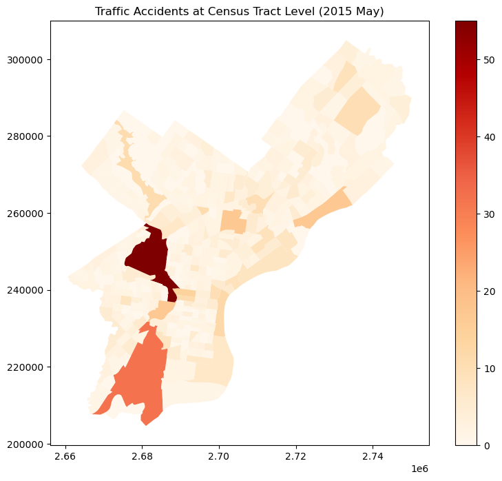

```python
import matplotlib.pyplot as plt

census_with_counts.plot(column="accident_count", cmap="OrRd", legend=True, figsize=(10, 8))
plt.title("Traffic Accidents at Census Tract Level (2015 May)")
plt.show()
```

install required module

安装模组

```python
!pip install fiona shapely rtree pyproj

import os
os.makedirs("output", exist_ok=True)

import fiona
from shapely.geometry import shape, mapping
from shapely.prepared import prep
from shapely.ops import transform
from rtree import index
from collections import defaultdict, Counter
from statistics import mean, median
from pyproj import CRS, Transformer
```

```python
POLYS = r"data/data/philadelphia-census-tract.shp"

polygons = []
with fiona.open(POLYS, "r") as poly_src:
    poly_crs = None
    # 优先用 wkt，没有再用 crs dict
    if getattr(poly_src, "crs_wkt", None):
        poly_crs = CRS.from_wkt(poly_src.crs_wkt)
    elif poly_src.crs:
        poly_crs = CRS.from_user_input(poly_src.crs)

    poly_schema = poly_src.schema.copy()   # 原 schema 备用（写出时用）

    for feat in poly_src:
        geom = shape(feat["geometry"])     # Shapely Polygon/MultiPolygon
        polygons.append({"geom": geom, "props": dict(feat["properties"])})

# Rtree：用面要素的包围盒建索引
rt = index.Index()
for i, p in enumerate(polygons):
    rt.insert(i, p["geom"].bounds)

# 预编译 polygon（提高 contains/within 判断效率）
prepped_polys = [prep(p["geom"]) for p in polygons]
```

### Read Accident Point (Point) + Multi-Condition Filtering (Display & With |)

### 读取事故点（Point）+ 多条件筛选（展示 & 与 |）

```python
POINTS = r"data/data/crash_data_collision_crash_2007_2017.shp"

# 想筛的条件（演示 & |）：
year = 2015
months = [5, 6]       # 5月 或 6月   —— 使用“或”（OR）
weekdays = [1, 5]     # 周一 或 周五 —— 使用“或”（OR）

points = []
with fiona.open(POINTS, "r") as pt_src:
    # 处理 CRS（和普查区一致时无需转换）
    pt_crs = None
    if getattr(pt_src, "crs_wkt", None):
        pt_crs = CRS.from_wkt(pt_src.crs_wkt)
    elif pt_src.crs:
        pt_crs = CRS.from_user_input(pt_src.crs)

    need_transform = (poly_crs is not None and pt_crs is not None and poly_crs != pt_crs)
    transformer = Transformer.from_crs(pt_crs, poly_crs, always_xy=True) if need_transform else None

    n_total = 0
    n_kept = 0

    for feat in pt_src:
        n_total += 1
        props = feat["properties"]
        y_ok = (props.get("crash_year") == year)                 # AND
        m_ok = (props.get("crash_mont") in months)               # (5 或 6)
        d_ok = (props.get("day_of_wee") in weekdays)             # (周一 或 周五)

        if y_ok and (m_ok) and (d_ok):                           # AND 的组合
            geom = shape(feat["geometry"])
            if need_transform:
                geom = transform(lambda x, y, z=None: transformer.transform(x, y), geom)
            points.append({"geom": geom, "props": props})
            n_kept += 1

print(f"读入点要素：{n_total} 条；符合条件：{n_kept} 条")
```

```
读入点要素：77462 条；符合条件：576 条
```

### 叠置（点落面）并汇总统计（count / mean / median）

```python
# 计数与数值统计容器
counts = Counter()                      # 每个面里有多少点
vals_mean_median = defaultdict(list)    # 用于存放每个面的数值列表（例如 max_severi）

severity_field = "max_severi"           # 若没有此字段，可换其它数值字段名或置 None

for pt in points:
    g = pt["geom"]
    # 先用 Rtree 粗筛候选多边形
    candidates = list(rt.intersection(g.bounds))
    # 精确判断：点是否在面内
    for pid in candidates:
        if prepped_polys[pid].contains(g):      # 对点来说 contains/within 等价
            counts[pid] += 1
            if severity_field is not None:
                v = pt["props"].get(severity_field)
                if v is not None:
                    try:
                        vals_mean_median[pid].append(float(v))
                    except:
                        pass
            break  # 一个点只记入一个面
```

```python
for pid, poly in enumerate(polygons):
    c = counts.get(pid, 0)
    poly["props"]["acc_ct"] = int(c)  # 事故数量

    if pid in vals_mean_median and len(vals_mean_median[pid]) > 0:
        poly["props"]["acc_mean_sev"]   = float(mean(vals_mean_median[pid]))
        poly["props"]["acc_median_sev"] = float(median(vals_mean_median[pid]))
    else:
        poly["props"]["acc_mean_sev"]   = None
        poly["props"]["acc_median_sev"] = None

print("统计完成：已为每个普查区写入 acc_ct / acc_mean_sev / acc_median_sev")
```

```
统计完成：已为每个普查区写入 acc_ct / acc_mean_sev / acc_median_sev
```

```python
OUT_SHP = r"output/tracts_with_stats_2015_MayJun_MonFri.shp"
OUT_CSV = r"output/tracts_with_stats_2015_MayJun_MonFri.csv"

# 基于原 schema，附加新的统计字段
out_schema = poly_schema.copy()
out_schema["properties"] = out_schema["properties"].copy()
out_schema["properties"]["acc_ct"]          = "int"
out_schema["properties"]["acc_mean_sev"]    = "float"
out_schema["properties"]["acc_median_sev"]  = "float"

# 用原 meta 写出（保持同一 CRS/driver）
with fiona.open(POLYS, "r") as src:
    meta = src.meta.copy()
meta["schema"] = out_schema

with fiona.open(OUT_SHP, "w", **meta) as dst:
    for p in polygons:
        dst.write({
            "geometry": mapping(p["geom"]),
            "properties": p["props"]
        })

# 再导出 CSV（便于快速查看/打分）
import csv
headers = list(polygons[0]["props"].keys())
with open(OUT_CSV, "w", newline="", encoding="utf-8") as f:
    w = csv.DictWriter(f, fieldnames=headers)
    w.writeheader()
    for p in polygons:
        w.writerow(p["props"])

print("已写出：")
print("  ", OUT_SHP)
print("  ", OUT_CSV)
```

```
已写出：
   output/tracts_with_stats_2015_MayJun_MonFri.shp
   output/tracts_with_stats_2015_MayJun_MonFri.csv
```

### 准备着色参数 (Prepare coloring parameters)

### 设置黑色底图 (Set black background)

### 绘制每个 tract 多边形 (Draw each tract polygon)

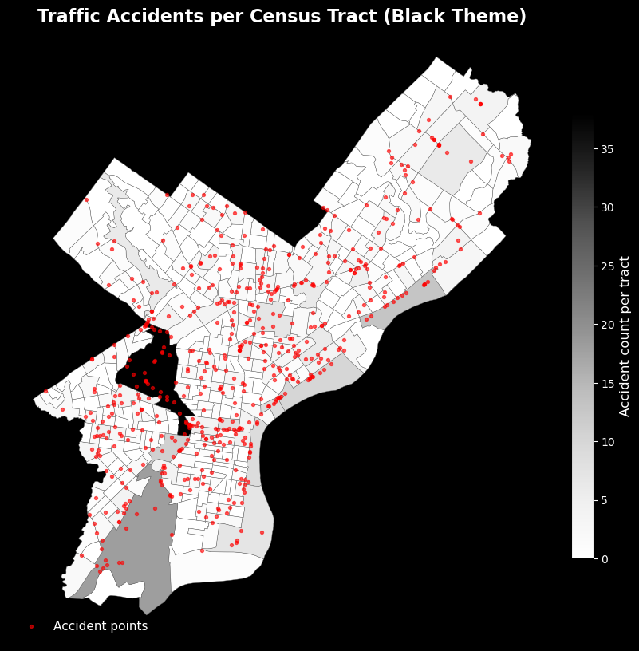

```python
import matplotlib.pyplot as plt
import matplotlib
from matplotlib.colors import Normalize
from matplotlib.cm import ScalarMappable
from shapely.geometry import Polygon, MultiPolygon

# 1) 准备着色：这次用灰度色图
counts = [p["props"].get("acc_ct", 0) for p in polygons]
vmin, vmax = 0, max(counts) if counts else 1
norm = Normalize(vmin=vmin, vmax=vmax)

cmap = matplotlib.colormaps["Greys"]  # 灰度底图
sm = ScalarMappable(norm=norm, cmap=cmap)

# 2) 设置黑底
fig, ax = plt.subplots(figsize=(12, 10), facecolor="black")
ax.set_facecolor("black")

# tract 多边形（灰度表示事故数量）
for p in polygons:
    geom = p["geom"]
    c = p["props"].get("acc_ct", 0)
    facecolor = cmap(norm(c))

    def draw_poly(poly):
        x, y = poly.exterior.xy
        ax.fill(x, y, facecolor=facecolor, edgecolor="dimgray", linewidth=0.3)
        for interior in poly.interiors:
            xi, yi = interior.xy
            ax.plot(xi, yi, color="dimgray", linewidth=0.3)

    if isinstance(geom, Polygon):
        draw_poly(geom)
    elif isinstance(geom, MultiPolygon):
        for sub in geom.geoms:
            draw_poly(sub)

# 事故点：红色，稍大，半透明
sc = None
if len(points) > 0:
    xs = [pt["geom"].x for pt in points]
    ys = [pt["geom"].y for pt in points]
    sc = ax.scatter(
        xs, ys,
        s=8,                # 稍大
        alpha=0.6,          # 半透明
        color="red",        # 红色点
        marker="o",
        label="Accident points"
    )

# 美化
ax.set_aspect("equal", adjustable="box")
ax.set_title(
    "Traffic Accidents per Census Tract (Black Theme)",
    fontsize=16, fontweight="bold", color="white"
)
ax.axis("off")

# colorbar（灰度 → 白色）
cbar = plt.colorbar(sm, ax=ax, fraction=0.03, pad=0.02)
cbar.set_label("Accident count per tract", fontsize=12, color="white")
cbar.ax.yaxis.set_tick_params(color="white")
plt.setp(cbar.ax.get_yticklabels(), color="white")

# 图例（红点）
if sc is not None:
    legend = ax.legend(loc="lower left", fontsize=11, frameon=False)
    plt.setp(legend.get_texts(), color="white")

plt.show()
```

```python
import os
os.getcwd()
```

```
'C:\\Users\\yanyang'
```

```python
import os
os.path.abspath("AI_assignment_1.ipynb")
```

```
'C:\\Users\\yanyang\\AI_assignment_1.ipynb'
```